# Cassie Winn R Assignment

# Part I

## Data Inspection

### Read In Files

```r
library(tidyverse)
genotypes <- read_tsv("./data/fang_et_al_genotypes.txt")
snp_position <- read_tsv("./data/snp_position.txt")
```

### Determine File Size

Use file.info to get size of file in bytes, whether the file is a directory, last status change and last access times, user ID of the file’s owner, username, group name, and other info.

```r
file.info("./data/fang_et_al_genotypes.txt")
```

```
##                                     size isdir mode               mtime
## ./data/fang_et_al_genotypes.txt 11051939 FALSE  644 2018-10-09 11:20:39
##                                               ctime               atime
## ./data/fang_et_al_genotypes.txt 2018-10-09 11:20:40 2018-10-11 20:58:39
##                                 uid gid          uname grname
## ./data/fang_et_al_genotypes.txt 501  20 cassandradohse  staff
```

```r
file.info("./data/snp_position.txt")
```

```
##                          size isdir mode               mtime
## ./data/snp_position.txt 82763 FALSE  644 2018-10-09 11:20:01
##                                       ctime               atime uid gid
## ./data/snp_position.txt 2018-10-09 11:20:01 2018-10-11 20:58:38 501  20
##                                  uname grname
## ./data/snp_position.txt cassandradohse  staff
```

If you just wanted file size in bytes use the function file.size()

```r
file.size("./data/fang_et_al_genotypex.txt")
```

```
## [1] NA
```

```r
file.size("./data/snp_position.txt")
```

```
## [1] 82763
```

### Determine Number of Lines

Simply type the name of the dataframe and it will give the dimensions for lines x columns (example: “A tibble: 983 x 15”)

```r
genotypes
```

```
## # A tibble: 2,782 x 986
##    Sample_ID JG_OTU Group abph1.20 abph1.22 ae1.3 ae1.4 ae1.5 an1.4 ba1.6
##    <chr>     <chr>  <chr> <chr>    <chr>    <chr> <chr> <chr> <chr> <chr>
##  1 SL-15     T-aus… TRIPS ?/?      ?/?      T/T   G/G   T/T   C/C   ?/?
##  2 SL-16     T-aus… TRIPS ?/?      ?/?      T/T   ?/?   T/T   C/C   A/G
##  3 SL-11     T-bra… TRIPS ?/?      ?/?      T/T   G/G   T/T   ?/?   G/G
##  4 SL-12     T-bra… TRIPS ?/?      ?/?      T/T   G/G   T/T   C/C   G/G
##  5 SL-18     T-cund TRIPS ?/?      ?/?      T/T   G/G   T/T   C/C   ?/?
##  6 SL-2      T-dac… TRIPS ?/?      ?/?      T/T   G/G   T/T   C/C   A/G
##  7 SL-4      T-dac… TRIPS ?/?      ?/?      T/T   G/G   T/T   C/C   G/G
##  8 SL-6      T-dac… TRIPS ?/?      ?/?      T/T   G/G   T/T   C/C   ?/?
##  9 SL-7      T-dac… TRIPS ?/?      ?/?      T/T   G/G   T/T   C/C   G/G
## 10 SL-5      T-dac… TRIPS ?/?      ?/?      T/T   G/G   T/T   C/C   ?/?
## # ... with 2,772 more rows, and 976 more variables: ba1.9 <chr>,
## #   bt2.5 <chr>, bt2.7 <chr>, bt2.8 <chr>, Fea2.1 <chr>, Fea2.5 <chr>,
## #   id1.3 <chr>, lg2.11 <chr>, lg2.2 <chr>, pbf1.1 <chr>, pbf1.2 <chr>,
## #   pbf1.3 <chr>, pbf1.5 <chr>, pbf1.6 <chr>, pbf1.7 <chr>, pbf1.8 <chr>,
## #   PZA00003.11 <chr>, PZA00004.2 <chr>, PZA00005.8 <chr>,
## #   PZA00005.9 <chr>, PZA00006.13 <chr>, PZA00006.14 <chr>,
## #   PZA00008.1 <chr>, PZA00010.5 <chr>, PZA00013.10 <chr>,
## #   PZA00013.11 <chr>, PZA00013.9 <chr>, PZA00015.4 <chr>,
## #   PZA00017.1 <chr>, PZA00018.5 <chr>, PZA00029.11 <chr>,
## #   PZA00029.12 <chr>, PZA00030.11 <chr>, PZA00031.5 <chr>,
## #   PZA00041.3 <chr>, PZA00042.2 <chr>, PZA00042.5 <chr>,
## #   PZA00043.7 <chr>, PZA00045.1 <chr>, PZA00047.2 <chr>,
## #   PZA00049.12 <chr>, PZA00050.9 <chr>, PZA00051.2 <chr>,
## #   PZA00058.5 <chr>, PZA00058.6 <chr>, PZA00060.2 <chr>,
## #   PZA00061.1 <chr>, PZA00065.2 <chr>, PZA00069.4 <chr>,
## #   PZA00070.5 <chr>, PZA00078.2 <chr>, PZA00079.1 <chr>,
## #   PZA00081.17 <chr>, PZA00084.2 <chr>, PZA00084.3 <chr>,
## #   PZA00086.8 <chr>, PZA00088.3 <chr>, PZA00090.2 <chr>,
## #   PZA00092.1 <chr>, PZA00092.5 <chr>, PZA00093.2 <chr>,
## #   PZA00096.26 <chr>, PZA00097.13 <chr>, PZA00098.14 <chr>,
## #   PZA00100.10 <chr>, PZA00100.12 <chr>, PZA00100.14 <chr>,
## #   PZA00100.9 <chr>, PZA00103.20 <chr>, PZA00106.9 <chr>,
## #   PZA00107.18 <chr>, PZA00108.12 <chr>, PZA00108.14 <chr>,
## #   PZA00108.15 <chr>, PZA00109.3 <chr>, PZA00109.5 <chr>,
## #   PZA00111.2 <chr>, PZA00111.4 <chr>, PZA00111.5 <chr>,
## #   PZA00111.6 <chr>, PZA00111.8 <chr>, PZA00114.3 <chr>,
## #   PZA00116.2 <chr>, PZA00119.4 <chr>, PZA00120.4 <chr>,
## #   PZA00123.1 <chr>, PZA00125.2 <chr>, PZA00131.14 <chr>,
## #   PZA00132.17 <chr>, PZA00132.18 <chr>, PZA00132.3 <chr>,
## #   PZA00135.6 <chr>, PZA00137.2 <chr>, PZA00139.14 <chr>,
## #   PZA00140.10 <chr>, PZA00140.6 <chr>, PZA00140.9 <chr>,
## #   PZA00142.6 <chr>, PZA00148.2 <chr>, PZA00153.3 <chr>, …
```

```r
snp_position
```

```
## # A tibble: 983 x 15
##    SNP_ID cdv_marker_id Chromosome Position alt_pos mult_positions amplicon
##    <chr>          <int> <chr>      <chr>    <chr>   <chr>          <chr>
##  1 abph1…          5976 2          27403404 <NA>    <NA>           abph1
##  2 abph1…          5978 2          27403892 <NA>    <NA>           abph1
##  3 ae1.3           6605 5          1678897… <NA>    <NA>           ae1
##  4 ae1.4           6606 5          1678896… <NA>    <NA>           ae1
##  5 ae1.5           6607 5          1678898… <NA>    <NA>           ae1
##  6 an1.4           5982 1          2404985… <NA>    <NA>           an1
##  7 ba1.6           3463 3          1813629… <NA>    <NA>           ba1
##  8 ba1.9           3466 3          1813626… <NA>    <NA>           ba1
##  9 bt2.5           5983 4          66290049 <NA>    <NA>           bt2
## 10 bt2.7           5985 4          66290994 <NA>    <NA>           bt2
## # ... with 973 more rows, and 8 more variables:
## #   cdv_map_feature.name <chr>, gene <chr>, `candidate/random` <chr>,
## #   Genaissance_daa_id <int>, Sequenom_daa_id <int>,
## #   count_amplicons <int>, count_cmf <int>, count_gene <int>
```

Or, use the function nrow() to give the number of rows/lines in a dataframe

```r
nrow(genotypes)
```

```
## [1] 2782
```

```r
nrow(snp_position)
```

```
## [1] 983
```

Or, use the function dim() to get rows and columns

```r
dim(genotypes)
```

```
## [1] 2782  986
```

```r
dim(snp_position)
```

```
## [1] 983  15
```

### Determine Number of Columns

Use ncol() function to determine number of columns in a dataframe

```r
ncol(genotypes)
```

```
## [1] 986
```

```r
ncol(snp_position)
```

```
## [1] 15
```

## Data Processing

### Extracting Info from Files

First, I extracted the maize and teosinte data and made two new corresponding files

```r
maize_genotypes <- subset(genotypes, Group == "ZMMIL" | Group == "ZMMLR" | Group == "ZMMMR")
teosinte_genotypes <- subset (genotypes, Group == "ZMPBA" | Group == "ZMPIL" | Group == "ZMPJA")
```

### Transpose

To transpose the data we can use function t()

```r
transposed_maize <- as.data.frame(t(maize_genotypes))
transposed_teosinte <- as.data.frame(t(teosinte_genotypes))
```

### Format Genotype Files and Sort

The transposed data does not include the header in the first column, so we need to add that in.

```r
if(!require("tibble")) install.packages("tibble")
library(tibble)

names(transposed_maize) <- lapply(transposed_maize[1,], as.character)
transposed_maize <- transposed_maize [-1,]

names(transposed_teosinte) <- lapply(transposed_teosinte[1, ], as.character)
transposed_teosinte <- transposed_teosinte[-1,]

transposed_maize <- rownames_to_column(transposed_maize, var="SNP_ID")
transposed_teosinte <- rownames_to_column(transposed_teosinte, var="SNP_ID")
```

We then sort the files by SNP_ID. To do that use the dplyr function arrange()

```r
if(!require("dplyr")) install.packages("dplyr")
library(dplyr)

transposed_teosinte <- arrange(transposed_teosinte, SNP_ID)
transposed_maize <- arrange(transposed_maize, SNP_ID)
```

### Format and Sort SNP File

First, I cut out the columns of snp_position.txt that are needed (SNP_ID, Chromosome and Position) and compiled them in one file in the order desired.

```r
snp_ID_chro_pos <- snp_position[, c("SNP_ID", "Chromosome", "Position")]
```

Before the SNP file can be joined with genotype files, it must be sorted by SNP_ID as well:

```r
snp_ID_chro_pos <- arrange(snp_ID_chro_pos, SNP_ID)
```

### Join SNP and Genotype Files

Join the SNP and Genotype files using merge()

```r
teosinte_join <- merge(snp_ID_chro_pos,transposed_teosinte, by.x="SNP_ID", by.y="SNP_ID", all = TRUE)

maize_join <- merge(snp_ID_chro_pos,transposed_maize, by.x="SNP_ID", by.y="SNP_ID", all = TRUE)
```

```r
teosinte_join <- subset(teosinte_join, !(teosinte_join$Chromosome == "unknown") | !(teosinte_join$Chromosome =="multiple"))

maize_join <- subset(maize_join, !(maize_join$Chromosome == "unknown") | !(maize_join$Chromosome == "multiple"))
```

### Extract Data for Input Files

Create 10 files (1 for each chromosome) where SNPs are ordered based on increasing position and missing data encoded by this symbol: ?

First, arrange the files with position sorted in ascending order

```r
teosinte_join_ascend <- arrange(teosinte_join, Position)
maize_join_ascend <- arrange(maize_join, Position)
```

To create the 10 files (1 for each chromosome) we use a for loop and write.csv() to create the files.

```r
setwd("./files/Maize")
for (i in 1:10) {
  x <- maize_join_ascend[maize_join_ascend$Chromosome == i,]
#we can create a new CSV file for each chromosome
  write.csv(x, sprintf("maize_increase_chrom_%d.csv", i), row.names = F)
}
```

Do the same for teosinte files.

```r
setwd("./files/Teosinte")
for (i in 1:10) {
  x <- teosinte_join_ascend[teosinte_join_ascend$Chromosome == i,]
#we can create a new CSV file for each chromosome
  write.csv(x, sprintf("teosinte_increase_chrom_%d.csv", i), row.names = F)
}
```

Create 10 files (1 for each chromosome) where SNPs are ordered based on decreasing position and missing data is encoded by this symbol: -

First, I order the dataframe in decreasing order

```r
teosinte_join_descend <- arrange(teosinte_join, desc(Position))
maize_join_descend <- arrange(maize_join, desc(Position))
```

Next, I change the symbol ? to - and again create the files for each chromosome.

```r
teosinte_join_descend[] <- lapply(teosinte_join_descend, as.character)
teosinte_join_descend[teosinte_join_descend == '?/?'] <- '-/-'

maize_join_descend[] <- lapply(maize_join_descend, as.character)
maize_join_descend[maize_join_descend == '?/?'] <- '-/-'
```

```r
setwd("./files/Maize")
for (i in 1:10) {
  x <- maize_join_descend[maize_join_descend$Chromosome == i,]
#we can create a new CSV file for each chromosome
  write.csv(x, sprintf("maize_decrease_chrom_%d.csv", i), row.names = F)
}
```

```r
setwd("./files/Teosinte")
for (i in 1:10) {
  x <- teosinte_join_descend[teosinte_join_descend$Chromosome == i,]
#we can create a new CSV file for each chromosome
  write.csv(x, sprintf("teosinte_decrease_chrom_%d.csv", i), row.names = F)
}
```

# Part 2

Load required packages

```r
if (!require("ggplot2")) install.packages("ggplot2")
library(ggplot2)

if(!require("tibble")) install.packages("tibble")
library(tibble)

if (!require("reshape2")) install.packages("reshape2")
library(reshape2)

if(!require("dplyr")) install.packages("dplyr")
library(dplyr)

if (!require("plyr")) install.packages("plyr")
library(plyr)
```

First, I transpose the genotypes file, add in the header and join it with the snp_position file to have a dataset ready for graphing.

```r
genotypes_transpose <- as.data.frame(t(genotypes))

names(genotypes_transpose) <- lapply(genotypes_transpose[1, ], as.character)
genotypes_transpose <- genotypes_transpose[-1,]
genotypes_transpose <- rownames_to_column(genotypes_transpose, var="SNP_ID")

genotypes_trans_join <- merge(snp_position,genotypes_transpose, by.x="SNP_ID", by.y="SNP_ID", all = TRUE)
```

### SNPs per chromosome

Plot the total number of SNPs in our dataset on each chromosome. What groups contribute most of these SNPs?

First, create a vector with the chromosomes in order.

```r
genotypes_trans_join$Chromosome <- factor(genotypes_trans_join$Chromosome, levels = c("1", "2", "3", "4", "5", "6", "7", "8", "9", "10", "multiple", "unknown", "NA"))
```

Create the graph using ggplot()

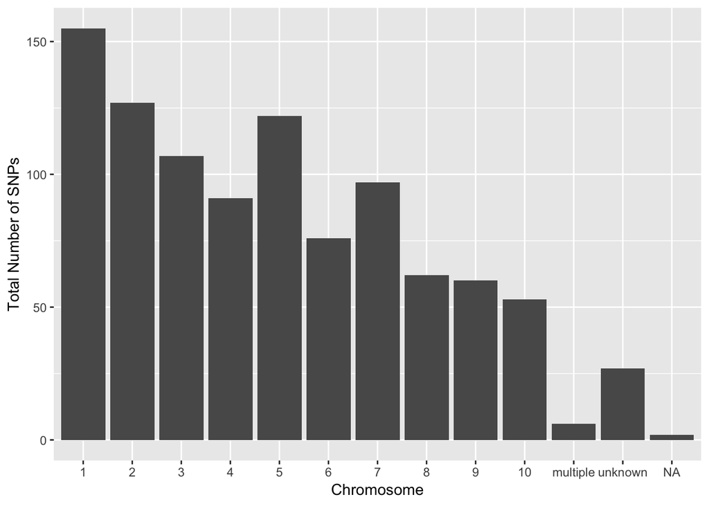

```r
ggplot(genotypes_trans_join) + geom_bar(aes(genotypes_trans_join$Chromosome)) + xlab("Chromosome") + ylab("Total Number of SNPs")
```

To look at which groups contribute most of these SNPs, use ggplot() to look at the original genotypes from fang_et_al_genotypes.txt

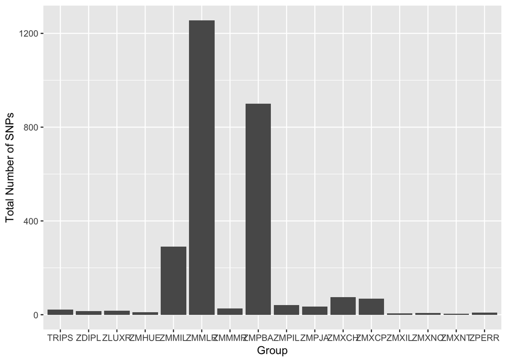

```r
ggplot(genotypes) + geom_bar(aes(genotypes$Group)) + xlab("Group") + ylab("Total Number of SNPs")
```

### Missing Data and Amount of Heterozygosity

Using melt() we put the individual value of each SNP in each of the sample_id and JG_OTU

```r
header <- colnames(genotypes)[-c(1:3)]
genotypes_melt <- melt(genotypes, measure.vars = header)
```

Change the symbol of missing data from ? to NA

```r
genotypes_melt[genotypes_melt == "?/?"] = NA
```

Create a new column for homozygotes using a logical statement of TRUE, FALSE, NA for the missing data. Then sort the data by Sample_ID and Group.

```r
genotypes_melt$Homozygote <- (genotypes_melt$value == "A/A" | genotypes_melt$value == "C/C" | genotypes_melt$value == "T/T" | genotypes_melt$value == "G/G")

genotypes_melt <- arrange(genotypes_melt, Sample_ID, Group)
```

Plot # of homozygotes and heterozygotes by sample_ID

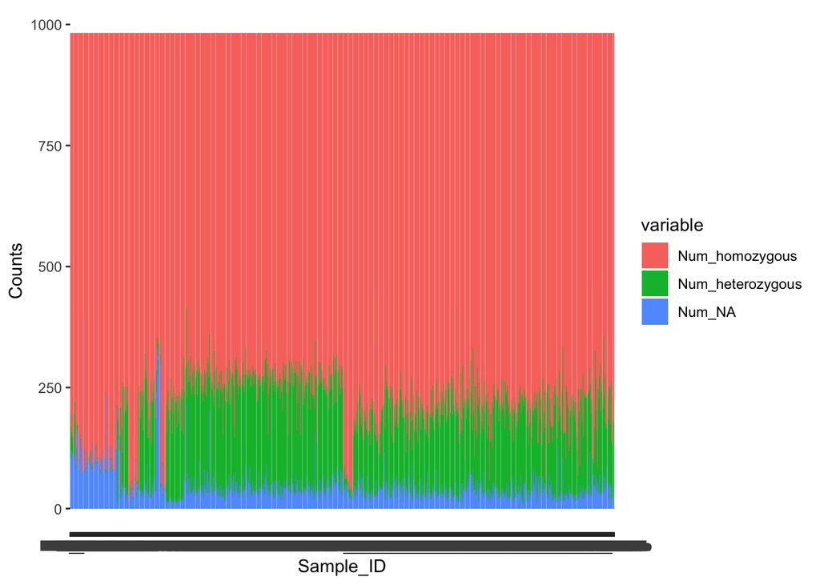

```r
counts_id <- ddply(genotypes_melt, c("Sample_ID"), summarise, Num_homozygous=sum(Homozygote, na.rm=TRUE), Num_heterozygous=sum(!Homozygote, na.rm=TRUE), Num_NA=sum(is.na(Homozygote)))

counts_id_melt <- melt(counts_id, measure.vars = c("Num_homozygous", "Num_heterozygous", "Num_NA"))
colnames(counts_id_melt)[3] <- "Counts"

ggplot(counts_id_melt, aes(x = Sample_ID, y= Counts, fill=variable)) + geom_bar(stat = "identity", position = "stack")
```

Plot homozygotes and heterozygotes by group

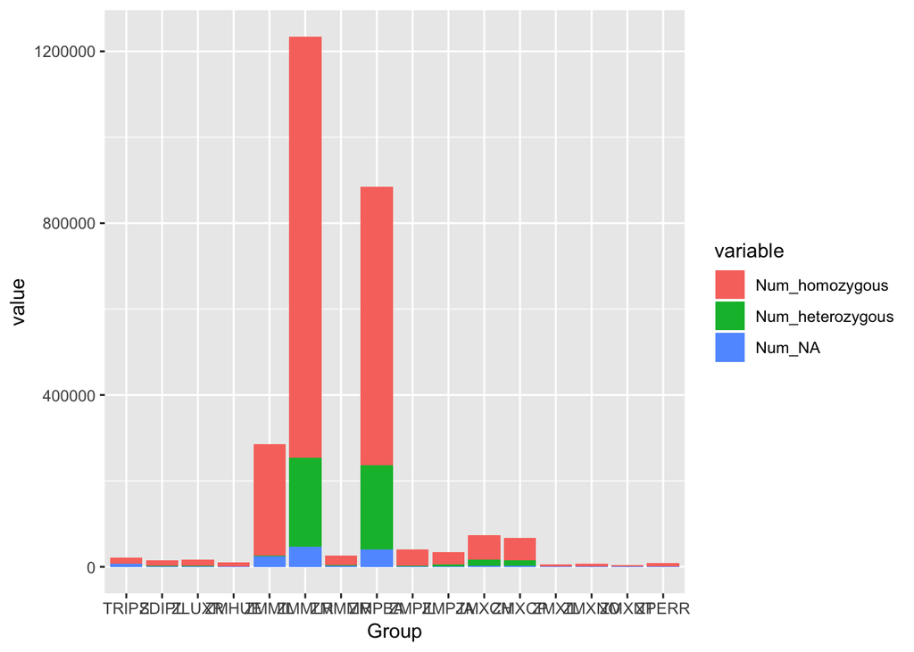

```r
counts_group <- ddply(genotypes_melt, c("Group"), summarise, Num_homozygous=sum(Homozygote, na.rm=TRUE), Num_heterozygous=sum(!Homozygote, na.rm=TRUE), Num_NA=sum(is.na(Homozygote)))

counts_group_melt <- melt(counts_group, measure.vars = c("Num_homozygous", "Num_heterozygous", "Num_NA"))

ggplot(counts_group_melt, aes(x = Group, y= value, fill=variable)) + geom_bar(stat = "identity", position = "stack")
```

### Own Data Visualization - Most common genotypes across loci and individuals

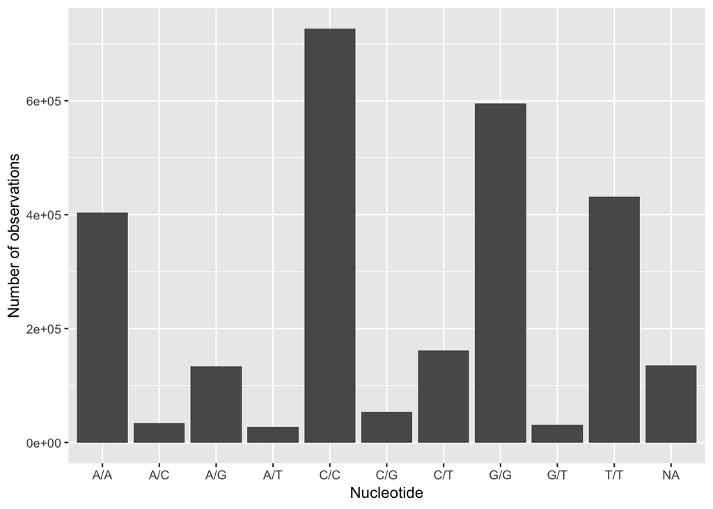

```r
ggplot(genotypes_melt)+ geom_bar(aes(genotypes_melt$value))+xlab("Nucleotide") +ylab("Number of observations")
```

### Own Data Visualization- Recombination Rate per Sample_ID

Compute recombination rate as total number of heterozygous loci over number of homozygous and heterozygous loci.

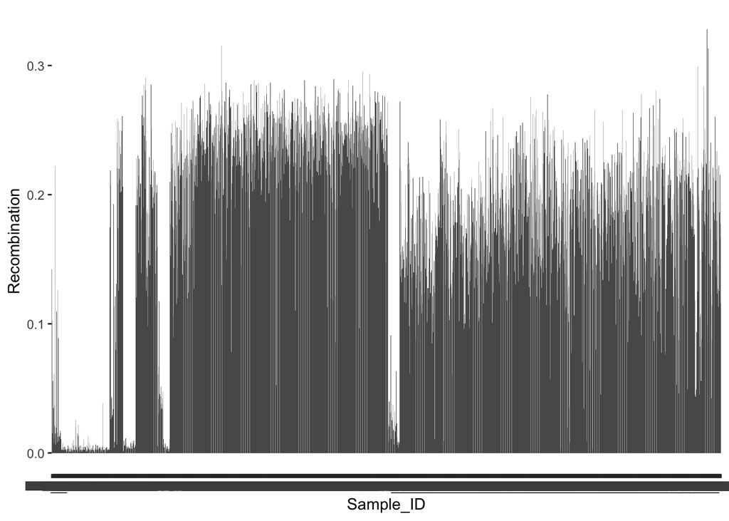

```r
hetero_per_locus <- ddply(genotypes_melt, c("Sample_ID"), summarise, hetero_count=sum(!Homozygote, na.rm=TRUE), total_count=sum(!Homozygote, Homozygote, na.rm=TRUE))

hetero_per_locus$Recombination <- (hetero_per_locus$hetero_count/hetero_per_locus$total_count)

ggplot(hetero_per_locus, aes(x = Sample_ID, y= Recombination)) + geom_bar(stat = "identity", position = "stack")
```